# Module 1, Lesson 4: Pseudo-random numbers and the t-test

Open a new R script. At the top of this script, load the `tidyverse` by writing the following in your script:

```r
library(tidyverse)
```

## Pseudo-random numbers in R

There are many reasons why it’s helpful to be able to generate random numbers. In our case, we want to generate random numbers to demonstrate use of the function for conducting t-tests in R.

However, computers cannot generate truly random numbers but rather so-called *pseudo* random numbers. Pseudo random numbers appear to be random but are actually pre-determined (very long) sequences of numbers that are nearly indistinguishable from truly random numbers. One implication of this is that if you start at the same point in the sequence as someone else, you will each obtain the same set of “random” numbers.

In R, you can choose where to start in this sequence by providing a so-called seed, using the `set.seed()` function:

```r
set.seed(1)
```

Above, we have set the seed to be equal to 1. In general, you can choose any positive integer as a seed (the largest possible seed on most computers is $2^{31}-1=2147483647$).

Now, to see what happens when you set a seed, let us sample twenty-five numbers from a normal distribution with mean 4.5 and standard deviation 0.5 using the `rnorm` function, which is named as such to make you think of ‘random normal’:

```r
rnorm(n = 25, mean = 4.5, sd = 0.5)
```

```
##  [1] 4.186773 4.591822 4.082186 5.297640 4.664754 4.089766 4.743715 4.869162
##  [9] 4.787891 4.347306 5.255891 4.694922 4.189380 3.392650 5.062465 4.477533
## [17] 4.491905 4.971918 4.910611 4.796951 4.959489 4.891068 4.537282 3.505324
## [25] 4.809913
```

Having generated some (pseudo) random numbers, we have advanced along the pre-determined sequence of numbers, meaning that if we run this same code again we will get a different set of numbers than above:

```r
rnorm(n = 25, mean = 4.5, sd = 0.5)
```

```
##  [1] 4.471936 4.422102 3.764624 4.260925 4.708971 5.179340 4.448606 4.693836
##  [9] 4.473097 3.811470 4.292503 4.302855 4.470343 5.050013 4.881588 4.417738
## [17] 4.373319 4.848482 4.778332 4.155622 4.146252 4.682291 4.884266 4.443827
## [25] 4.940554
```

However, if we re-set the seed to be 1 and run the code, this time assigning the results to an object named `x` so that we can use them later, we get the initial values back:

```r
set.seed(1)
x <- rnorm(n = 25, mean = 4.5, sd = 0.5)
x
```

```
##  [1] 4.186773 4.591822 4.082186 5.297640 4.664754 4.089766 4.743715 4.869162
##  [9] 4.787891 4.347306 5.255891 4.694922 4.189380 3.392650 5.062465 4.477533
## [17] 4.491905 4.971918 4.910611 4.796951 4.959489 4.891068 4.537282 3.505324
## [25] 4.809913
```

Notice how these 25 numbers are *identical* to the first 25 numbers we sampled above.

It is not required that you set a seed in R. When R needs one and you haven’t set it, it will choose one silently and automatically. We are doing so here for purposes of reproducibility: so that you can exactly reproduce the steps and results as you read along.

## The `t.test` function

We can visualize the numbers in `x` using `ggplot`:

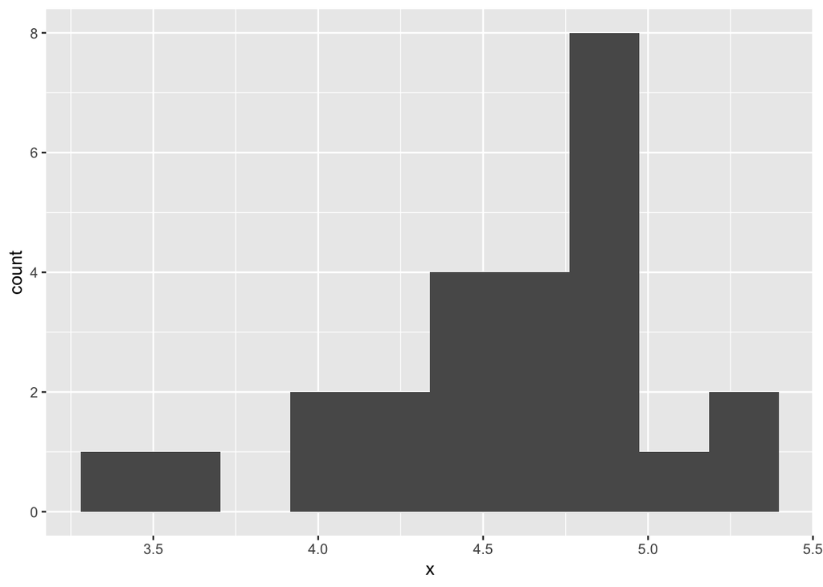

```r
ggplot() +
  geom_histogram(aes(x = x), bins = 10)
```

Because we generated these data ourselves, we know that they are normally distributed, meaning that the true shape of the distribution is the familiar bell-shape. However, because of *sampling variability*, the histogram of these twenty-five numbers doesn’t look particularly normal. Let’s create another sample from a normal distribution with a mean of 3 (be sure not to re-set the seed):

```r
y <- rnorm(n = 25, mean = 3, sd = 0.5)
y
```

```
##  [1] 2.971936 2.922102 2.264624 2.760925 3.208971 3.679340 2.948606 3.193836
##  [9] 2.973097 2.311470 2.792503 2.802855 2.970343 3.550013 3.381588 2.917738
## [17] 2.873319 3.348482 3.278332 2.655622 2.646252 3.182291 3.384266 2.943827
## [25] 3.440554
```

If you ran the steps exactly as above, then your `y` should be identically equal to the `y` that you see printed to the screen.

Before we demonstrate the function for conducting t-tests, remember that we already *know* whether `x` and `y` come from distributions having different means, because we generated these data as such! With the caveat, let us see how we would use the `t.test` function (which comes pre-installed with R) to test for a difference in means.

```r
t.test(x, y)
```

```
##
##  Welch Two Sample t-test
##
## data:  x and y
## t = 13.247, df = 44.32, p-value < 2.2e-16
## alternative hypothesis: true difference in means is not equal to 0
## 95 percent confidence interval:
##  1.329673 1.806761
## sample estimates:
## mean of x mean of y
##  4.584333  3.016116
```

As you can see, this function outputs several pieces of information to the screen. We see that `t = 13.247`, meaning that the t-statistic is 13.247. If the null hypothesis – namely that `x` and `y` come from distributions with the same mean – is true, then this t-statistic has arisen from a so-called t-distribution, centered at zero, with approximately 44.32 degrees of freedom. This t-statistic will tend to be ‘close’ to zero if the null hypothesis is true. The p-value is the probability that this t-statistic, or an even larger t-statistic, could have arisen from this null t-distribution. It is incredibly small: `2.2e-16` is R’s notation for $2.2\times 10^{-16}$. Thus, we would conclude that these data are extremely unlikely to have come from distributions where the null hypothesis is true.

**It is tempting, but incorrect, to say that the p-value is the probability that the null hypothesis is true.**

We also have a 95 confidence interval for the difference in the means. The probability that this interval covers the true difference in the means is 0.95. Or, put differently, if we were to repeat this experiment 100 times, we would expect that about 95 of these intervals would cover the true difference in the means (in fact, we know that the true difference in the means is 1.5).

Finally, the function reports the sample means of the observations from each group: the average value in `x` is 4.584 and the average value in `y` is 3.016.

## How to think about a t-test

In this part of the independent guide, we will get a better sense of how to think about conducting a t-test. We will use a function called `simulate_t` from the `healthds` package, which will need to be loaded into your R session:

```r
library(healthds)
```

The `simulate_t` function is a helper function we have developed to repeat the steps we did above (sample data from one group, sample data from a second group, conduct the t-test, and inspect the results) multiple times.

Here we will use `simulate_t` to conduct a single t-test on simulated data:

```r
set.seed(1)
simulate_t(rep = 1, mean = 4.5, mean2 = 3, n1 = 25, n2 = 25, sd = 0.5)
```

```
## # A tibble: 1 × 1
##       t
##   <dbl>
## 1  13.2
```

The output is a tibble (remember from Course 1 that the tibble is one way to store data in R). If we wanted to conduct 20 t-tests, we could run the following:

```r
simulate_t(rep = 20, mean = 4.5, mean2 = 3, n1 = 25, n2 = 25, sd = 0.5)
```

```
## # A tibble: 20 × 1
##        t
##    <dbl>
##  1 11.2
##  2 14.3
##  3 10.4
##  4 10.2
##  5 10.8
##  6 11.9
##  7  9.54
##  8 11.2
##  9  8.24
## 10 10.3
## 11  9.87
## 12 11.5
## 13  9.90
## 14  9.29
## 15 10.0
## 16  7.65
## 17 10.3
## 18  9.98
## 19  8.91
## 20 10.0
```

Now we have simulated 20 t-tests, using different data for each test but drawn from the same distribution. **Remember that in actual research, one typically collects data and conducts exactly one t-test.** In contrast, using simulation techniques, here we can do as many t-tests as we want – not so that we can learn about the true distribution of the data (we are in control of that distribution, so we don’t need to learn about it) but rather to see how t statistics are distributed when, in truth, a difference between the means exists or when there is no difference between the means.

Let’s consider this second scenario of no differences between the means. We will first generate 2000 t-statistics and pipe that into a call to `ggplot` to create a histogram of these 2000 values:

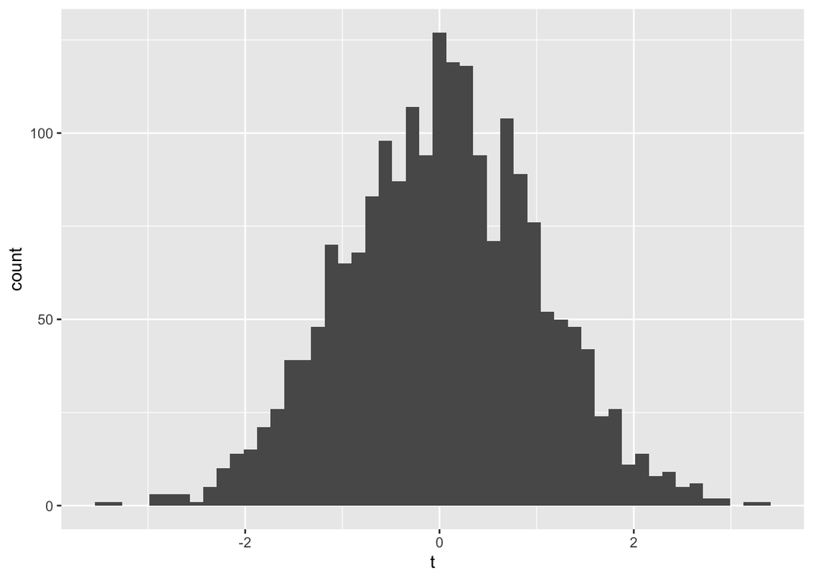

```r
simulate_t(rep = 2000, mean = 3, mean2 = 3, n1 = 25, n2 = 25, sd = 0.5) %>%
  ggplot() +
  geom_histogram(aes(x = t), bins = 50)
```

(For those of you paying close attention to the videos, you will see that this histogram doesn’t exactly match the same histogram we created in the Guided Practice. The reason is subtle but has to do with pseudo-random numbers and the fact that here we skipped one of the examples from the Guided Practice video.)

The resulting histogram is centered at zero. Importantly, in the situation where there is no difference between the means, we know what this distribution should look like without needing to conduct a simulation; sometimes this is called the ‘null distribution’. And because of this we can compare our observed t-statistic to the left and right extremes of the null distribution. We calculate the p-value, which is defined as probability of observing a t-statistic that is at least as large (in magnitude, meaning we ignore the sign) as the one we actually observed under the assumption that there is no difference in the means, i.e. when compared against the null distribution.

If this p-value is small, then that means it is unlikely that our t-statistic arose from this scenario, and so we would conclude that the data must have come from a scenario where the means are not equal. On the other hand, if the p-value is large, then all that means is that we cannot make that conclusion; it does not mean that the difference in the means is zero, but just that we couldn’t conclude as such.

The probability of concluding that the data came from a scenario where the means are not equal increases as the *true* difference in the means increases. For example, if we generate data from a scenario where the true difference is only 0.25, we get a slight shift away from zero.

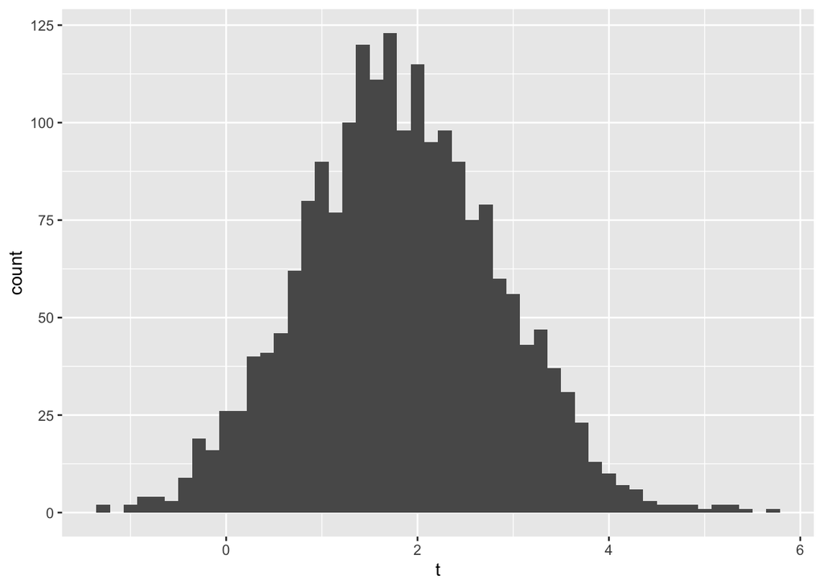

```r
simulate_t(rep = 2000, mean = 3.25, mean2 = 3, n1 = 25, n2 = 25, sd = 0.5) %>%
  ggplot() +
  geom_histogram(aes(x = t), bins = 50)
```

By random chance, we might observe a t-statistic that is, for example, equal to 1, and such a t-statistic is not that extreme when compared to the null distribution.

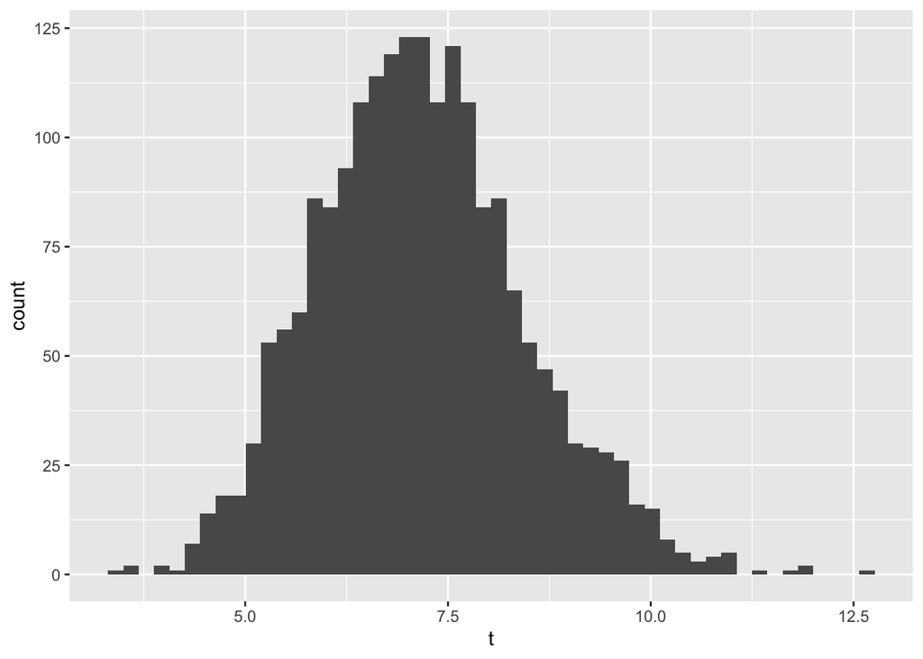

```r
simulate_t(rep = 2000, mean = 4.5, mean2 = 3.5, n1 = 25, n2 = 25, sd = 0.5) %>%
  ggplot() +
  geom_histogram(aes(x = t), bins = 50)
```

Our task is easier when, in truth, there is greater separation between the two groups.